# Observational Data Analysis

Compiled on Fri Aug 17 10:34:21 2018

## Response:

For this initial analysis of obsevational data, I chose a quite restrictive subset of sites with:

- 30 plots total
- 3 blocks
- Pretreatment soil data on the three relevant nutrients (N, P, K)

## Questions:

- Are measures of N, P, and K correlated with one another in sites? Or is variation of soil characteristics independent from one another?
- How well do soil variables explain within-site variation in community composition? What proportion of variance can be explained by soil nutrient Z-scores?
- Is the proportion of variance explained by soil nutrients dependent on variation in the soil resources themselves? I.e. is the influence of N, P, and K dependent on respective coefficients of variation of these resources?
- How correlated are community axis loadings of of N, P and K to one another? Are these relationships negative signalling some sort of resource use trade-off, or positive, suggesting that communities respond relatively uniformly to increased productivity?

## Methods:

- Subsetting species matrix and soil data to relevant sites
- Calculating Z-scores for soil nutrients
- Running canonical correspondence analysis (CCA) on site-wide community variance
- Extracting p-value of CCA, prop. variance explained, and predicted relationships between communities and environmnetal variables

## Highlights

- Weak correlations among soil resource (N, P, and K) Z-scores
- Substantial between-site differences in proportion variance explained by CCA
- Significant relationship between site-wide nitrogen coefficient of variation and CCA results.
- General positive pairwise correlations between SMAs of community relationships between N, P, and K.

## Analysis:

(Hidden in markdown output – see source file)

### Are measures of N, P, and K correlated with one another?

```
## N-P Z-score Corr: 0.277144055855892
## N-K Z-score Corr: 0.229080498328788
## P-K Z-score Corr: 0.363409576154242
```

### What sites exhibit the greatest proportion of community variance explained by soil nutrient Z-scores?

Here I’ve run a CCA (may have some favorable properties relative to RDA, but functions similarly) on each site, which should allow us to determine:

- What fraction of the overall variance in observational community composition we can attribute to variation in soil N, P, and K (and to test this fraction with ANOVA)
- What is the estimated relationship between community composition and soil characteristics (plot scores on N, P, and K axes)

Because I’ve subset our data to just those plots containing 30 plots in three blocks, these comparisons should be done with very similar datasets - similar to Jon Bakker’s approach.

Here we see that a number of sites have significant fractions of community variance that can be explained by soil variables in CCA, and there’s quite a range therein.

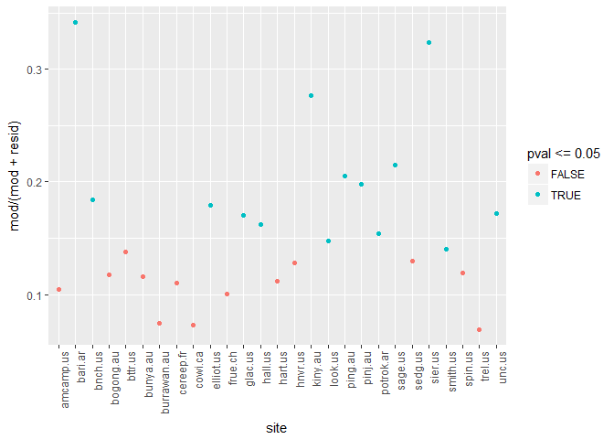

### What sites show the greatest amount of variance attributable to soil resource variation?

Relating this variance fraction to CV’s of N, P, and K shows an interesting, although not unexpected, pattern where the amoung of variance explained by soil nutrient Z-scores was correlated with the CV of nitrogen.

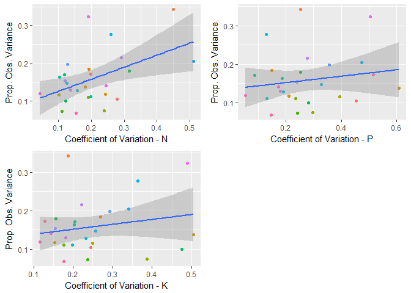

```
## Anova Table (Type II tests)
##
## Response: varfrac
##                  Sum Sq Df F value  Pr(>F)
## CV_n           0.027032  1  6.5488 0.01919 *
## CV_p           0.000420  1  0.1017 0.75331
## CV_k           0.003189  1  0.7726 0.39040
## CV_n:CV_p      0.005392  1  1.3061 0.26729
## CV_n:CV_k      0.001192  1  0.2887 0.59727
## CV_p:CV_k      0.001042  1  0.2524 0.62119
## CV_n:CV_p:CV_k 0.006047  1  1.4651 0.24097
## Residuals      0.078428 19
## ---
## Signif. codes:  0 '***' 0.001 '**' 0.01 '*' 0.05 '.' 0.1 ' ' 1
```

### How correlated are community axis loadings of of N, P and K to one another? Are these relationships negative signalling some sort of resource use trade-off, or positive, suggesting that communities respond relatively uniformly to increased productivity?

There’s quite a bit of variation in the slope of these relationships. Some show very strong positive relationships, while others are more negative.

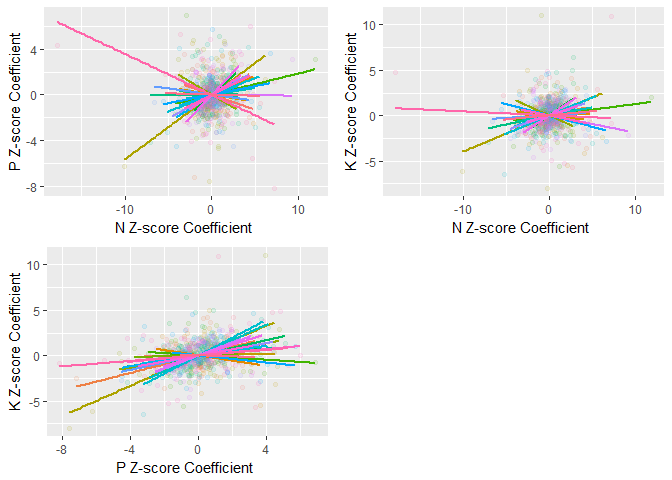

```
## N-P Corr: 0.0960983831632756
## N-K Corr: 0.103402424003949
## P-K Corr: 0.300051700032506
```

### Describing the above relationships with SMAs

I’ve repurposed your code here to explain these same relationships using SMAs. As before, significant relationships are in black, non-significant relationships are in grey. Generally, estimated community responses to N, P, and K are positive, though there may be a few negative relationships. Only one of these appears to be significant, and may be very outlier driven. Would be worth to check on these soil measurements.

As an aside, the SMAs don’t seem to ever assume a flat line. Is this a feature of the method? Or of the data itself?

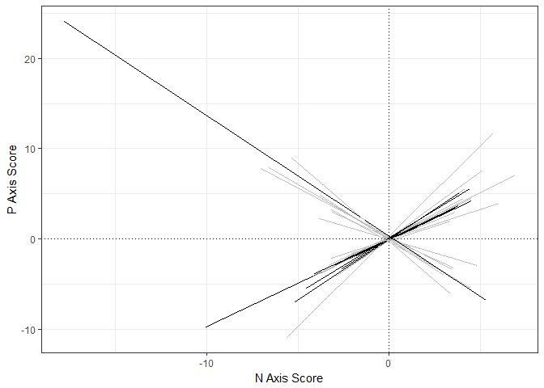

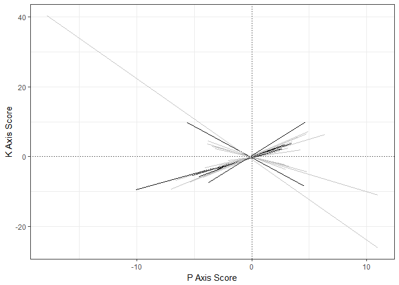

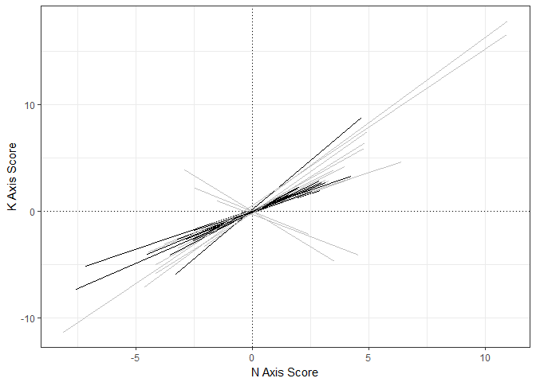